# Intersections of circles and rectangles

Fri May 14 18:51:10 2021

We’d like to calculate the proportion of a circle that intersects a rectangle, specifically when the center of the circle is *inside* the rectangle and the axes of the rectangle are aligned with the $x$ and $y$ axes.

Suppose the circle is centered at $(x, y)$ with radius $r$, and the rectangle edges are at $(a_1, a_2)$ with $a_1 < x < a_2$ and $(b_1, b_2)$ with $b_1 < y < b_2$, respectively. We’d like to calculate the blue area, and will do that by calculating the hatched areas, and their intersections, and subtracting.

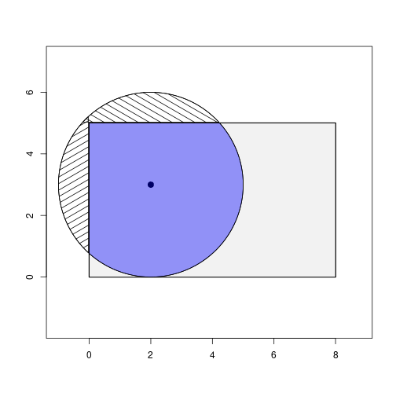

First consider the area of a semi-circular segment, like so:

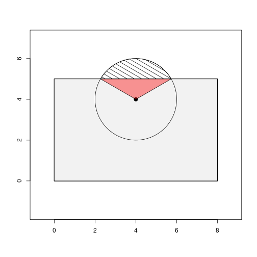

Next consider the area in the *overlap* of two such segments, as one obtains by the intersection of a circle with the corner of a rectangle. To do this, let $P$ be the area of the ice cream cone (which leans off at a precarious angle to the left in the diagram), $T_1$ the area of the red triangle, $T_2$ the area of the blue triangle, and $R$ the area of the rectangle with sides equal to the bases of the two triangles. Then the area we want (the double-hatched area below) is equal to $P - T_1 - T_2 + R$:

[output not shown]

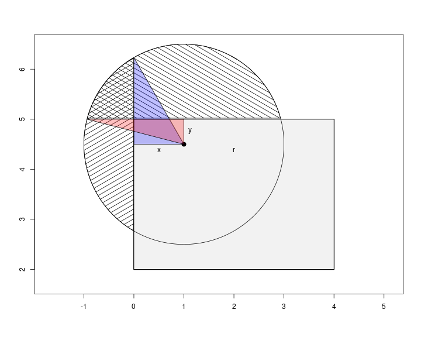

and let $z_i$ be the area of region $i$, then
$$\begin{aligned}
P &= z_1 + z_2 + z_3 + z_4 \\
T_B &= z_2 + z_4 + z_6 \\
T_R &= z_3 + z_4 + z_5 \\
R &= z_4 + z_5 + z_6 \\
\text{and so } P - T_1 - T_2 + R &= z_1 .
\end{aligned}$$

Now, let $x$ be the horizontal distance of the center of the circle to the vertical edge and $y$ the vertical distance to the horizontal edge. Then the angle of the vertex of the red triangle that’s at the center of the circle is
$$\theta_R = \cos^{-1}(y/r) ,$$
and the same thing for the blue triangle is
$$\theta_B = \cos^{-1}(x/r) .$$
Therefore, the angle of the base of the ice cream cone is
$$\theta = \theta_R + \theta_B - \pi/2,$$
and so
$$\begin{aligned}
P &= \pi r^2 \left( \frac{\theta}{2 \pi} \right) \\
&= \frac{r^2}{2} \left( \cos^{-1}(y/r) + \cos^{-1}(x/r) - \pi/2 \right) .
\end{aligned}$$
The remaining areas are easy:
$$\begin{aligned}
T_B &= \frac{1}{2} x \sqrt{r^2 - x^2} \\
T_R &= \frac{1}{2} y \sqrt{r^2 - y^2} \\
R &= xy .
\end{aligned}$$

Putting it all together, we have that
$$\begin{aligned}
A_2(x,y)
&= \frac{r^2}{2} \left( \cos^{-1}(y/r) + \cos^{-1}(x/r) - \pi/2 \right) \\
&\qquad - \frac{1}{2} x \sqrt{r^2 - x^2} \\
&\qquad - \frac{1}{2} y \sqrt{r^2 - y^2} \\
&\qquad + xy .
\end{aligned}$$

OK, let’s test this. To put this together into a general formula, we need to

```r
A1 <- function (x, r) {
    out <- 0
    if (x < r) {
        out <- r^2 * acos(x/r) - x * sqrt(r^2 - x^2)
    }
    return(out)
}

A2 <- function (x, y, r) {
    out <- 0
    if (x^2 + y^2 < r^2) {
        out <- (
                (r^2 / 2) * (acos(y/r) + acos(x/r) - pi/2)
                - x * sqrt(r^2 - x^2) / 2
                - y * sqrt(r^2 - y^2) / 2
                + x * y
               )
    }
    return(out)
}

area <- function (r, xy, a, b) {
    # Find the area of the intersection of the circle centered at xy with radius r
    # and the radius with vertical sides at a and horizontal sides at b.
    # xy, a, and b must be vectors of length 2, and xy must lie within the rectangle.
    stopifnot(length(xy) == 2 && length(a) == 2 && length(b) == 2)
    x1 <- xy[1] - a[1]
    x2 <- a[2] - xy[1]
    y1 <- xy[2] - b[1]
    y2 <- b[2] - xy[2]
    stopifnot(min(x1, x2, y1, y2) >= 0)
    A <- (
          A1(x1, r)
          + A1(x2, r)
          + A1(y1, r)
          + A1(y2, r)
          - A2(x1, y1, r)
          - A2(x1, y2, r)
          - A2(x2, y1, r)
          - A2(x2, y2, r)
         )
    stopifnot(A >= 0)
    stopifnot(A <= pi * r^2)
    return(pi * r^2 - A)
}
```

Now the tricky part: validation. We’ll do a Riemann integral of the area inside of the rectangle.

```r
integrate <- function (r, xy, a, b) {
    tt <- seq(0, 2*pi, length.out=10001)
    x = pmin(a[2], pmax(a[1], xy[1] - r * cos(tt)))
    y = pmin(b[2], pmax(b[1], xy[2] + r * sin(tt)))
    A <- sum(diff(x) * (y[-1] - diff(y)/2))
    return(A)
}

# integrates circles correctly?
for (k in 1:10) {
    stopifnot(abs(
        integrate(k, c(0, 0), c(-100, 100), c(-100, 100))
        - pi * k^2
        ) < 1e-3)
}
```

First, let’s try it on our simple examples above:

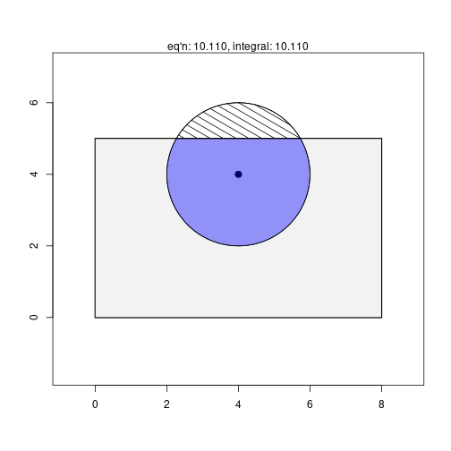

```
## [1] 10.10963 10.10963
```

```r
test <- function (r, xy, a, b, plot=TRUE) {
    A <- area(r, xy, a, b)
    iA <- integrate(r, xy, a, b)
    plot_intersection(r, xy, a, b)
    mtext(sprintf("eq'n: %0.3f, integral: %0.3f", A, iA), side=3)
    return(c(A, iA))
}
test(r=2, xy=c(4,4), a=c(0, 8), b=c(0, 5))
```

Looks good!! Now, for an intermediate:

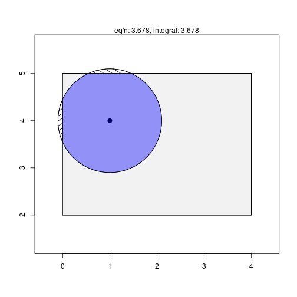

```
## [1] 3.677969 3.677969
```

```r
test(r=1.1, xy=c(1, 4.0), a=c(0, 4), b=c(2, 5))
```

Great! And, our second example, with positive overlap:

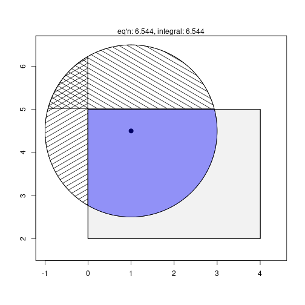

```
## [1] 6.544299 6.544299
```

```r
test(r=2, xy=c(1, 4.5), a=c(0, 4), b=c(2, 5))
```

Ok, now let’s try it on a bunch of random circles:

```r
layout(matrix(1:100, nrow=10, ncol=10))
par(mar=c(0,0,0,0)+.1)
AA <- matrix(NA, nrow=100, ncol=2)
for (k in 1:100) {
    r <- 2 * rexp(1)
    a <- sort(runif(2, -4, 4))
    b <- sort(runif(2, -4, 4))
    xy <- runif(2, c(a[1], b[1]), c(a[2], b[2]))
    AA[k,] <- test(r=r, xy=xy, a=a, b=b)
}
```

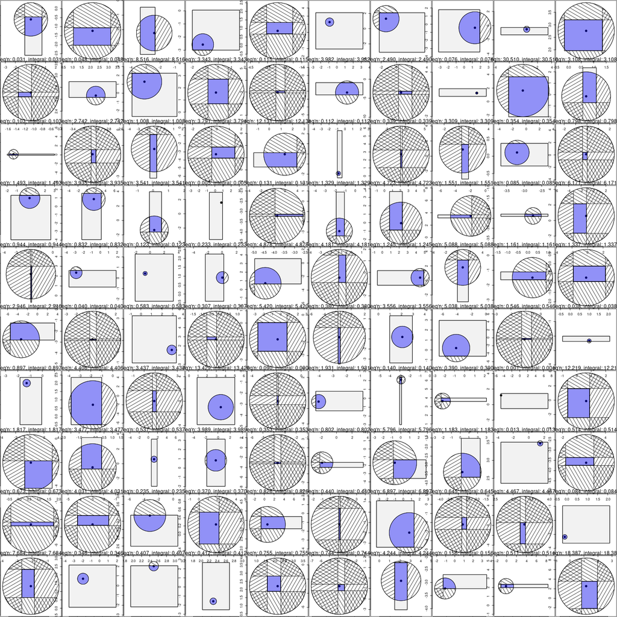

And, the results:

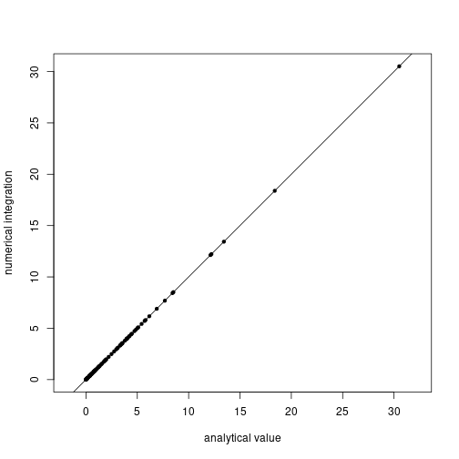

```r
plot(AA[,1], AA[,2], asp=1, xlab='analytical value', ylab='numerical integration', pch=20)
abline(0, 1)
```